# Project: TMDB Movie Analysis

- Introduction
- Data Wrangling
- Exploratory Data Analysis
- Conclusions

## Introduction

### Dataset Description

This data set contains information about 10,000 movies collected from The Movie Database (TMDb), including user ratings and revenue.

The dataset has 21 columns and 10,000 records. The columns are:

- id, imdb_id, popularity, budget, revenue, original_title, cast, homepage, director, tagline, keywords, overview, runtime, genres, production_companies, release_date, vote_count, vote_average, release_year, budget_adj, and revenue_adj.

### Question(s) for Analysis

1. What are the top 10 movies with the highest runtime?
2. What are the top 10 movies with the highest revenue? Compare with the revenue_adj.
3. What are the top 10 movies with the highest budget? Compare with the budget_adj.
4. What are the most popular movies based on popularity score?
5. In what year was the highest total revenue generated?
6. What is the total number of movies produced each year?
7. Which year has the highest total budget?
8. Do movies with long runtime cost more money to make? Is there a correlation between runtime and budget?
9. Do movies with long runtime have higher revenue? Is there a correlation between runtime and revenue?
10. Do movies with a high budget generate high revenue? Is there a correlation between budget and revenue?
11. Is there a correlation between revenue and revenue_adj?
12. Is there a correlation between budget and budget_adj?
13. Is there a relationship between vote count and vote average
14. Are movies with high vote counts more popular? (compare vote count and popularity score)
15. Do popular movies generate more revenue?
16. Which Movie Genre has the highest number of movies?
17. Which movie genre generated the highest average revenue? (Compare Action, Adventure, Thriller, Drama, Sci-Fi)
18. Which movie genre has the highest average budget? (Compare Action, Adventure, Thriller, Drama, Sci-Fi)
19. Which movie genre has the highest average vote count? (Compare Action, Adventure, Thriller, Drama, Sci-Fi)
20. Which movie genre has the highest average vote average? (Compare Action, Adventure, Thriller, Drama, Sci-Fi)
21. Which movie genre has the highest average runtime? (Compare Action, Adventure, Thriller, Drama, Sci-Fi)
22. Which movie genre has the highest average popularity score? (Compare Action, Adventure, Thriller, Drama, Sci-Fi)

```python
# import libraries
import numpy as np
import pandas as pd
import matplotlib.pyplot as plt
%matplotlib inline
```

```python
# Upgrade pandas to use dataframe.explode() function.
!pip install --upgrade pandas==0.25.0
```

## Data Wrangling

```python
# load dataset
df = pd.read_csv('Database_TMDb_movie_data/tmdb-movies.csv')
df.head()
```

|  | id | imdb_id | popularity | budget | revenue | original_title | cast | homepage | director | tagline | ... | overview | runtime | genres | production_companies | release_date | vote_count | vote_average | release_year | budget_adj | revenue_adj |
| --- | --- | --- | --- | --- | --- | --- | --- | --- | --- | --- | --- | --- | --- | --- | --- | --- | --- | --- | --- | --- | --- |
| 0 | 135397 | tt0369610 | 32.985763 | 150000000 | 1513528810 | Jurassic World | Chris Pratt\|Bryce Dallas Howard\|Irrfan Khan\|Vi... | http://www.jurassicworld.com/ | Colin Trevorrow | The park is open. | ... | Twenty-two years after the events of Jurassic ... | 124 | Action\|Adventure\|Science Fiction\|Thriller | Universal Studios\|Amblin Entertainment\|Legenda... | 6/9/15 | 5562 | 6.5 | 2015 | 1.379999e+08 | 1.392446e+09 |
| 1 | 76341 | tt1392190 | 28.419936 | 150000000 | 378436354 | Mad Max: Fury Road | Tom Hardy\|Charlize Theron\|Hugh Keays-Byrne\|Nic... | http://www.madmaxmovie.com/ | George Miller | What a Lovely Day. | ... | An apocalyptic story set in the furthest reach... | 120 | Action\|Adventure\|Science Fiction\|Thriller | Village Roadshow Pictures\|Kennedy Miller Produ... | 5/13/15 | 6185 | 7.1 | 2015 | 1.379999e+08 | 3.481613e+08 |
| 2 | 262500 | tt2908446 | 13.112507 | 110000000 | 295238201 | Insurgent | Shailene Woodley\|Theo James\|Kate Winslet\|Ansel... | http://www.thedivergentseries.movie/#insurgent | Robert Schwentke | One Choice Can Destroy You | ... | Beatrice Prior must confront her inner demons ... | 119 | Adventure\|Science Fiction\|Thriller | Summit Entertainment\|Mandeville Films\|Red Wago... | 3/18/15 | 2480 | 6.3 | 2015 | 1.012000e+08 | 2.716190e+08 |
| 3 | 140607 | tt2488496 | 11.173104 | 200000000 | 2068178225 | Star Wars: The Force Awakens | Harrison Ford\|Mark Hamill\|Carrie Fisher\|Adam D... | http://www.starwars.com/films/star-wars-episod... | J.J. Abrams | Every generation has a story. | ... | Thirty years after defeating the Galactic Empi... | 136 | Action\|Adventure\|Science Fiction\|Fantasy | Lucasfilm\|Truenorth Productions\|Bad Robot | 12/15/15 | 5292 | 7.5 | 2015 | 1.839999e+08 | 1.902723e+09 |
| 4 | 168259 | tt2820852 | 9.335014 | 190000000 | 1506249360 | Furious 7 | Vin Diesel\|Paul Walker\|Jason Statham\|Michelle ... | http://www.furious7.com/ | James Wan | Vengeance Hits Home | ... | Deckard Shaw seeks revenge against Dominic Tor... | 137 | Action\|Crime\|Thriller | Universal Pictures\|Original Film\|Media Rights ... | 4/1/15 | 2947 | 7.3 | 2015 | 1.747999e+08 | 1.385749e+09 |

5 rows × 21 columns

```python
# check the columns in the datasest
df.columns
```

```
Index(['id', 'imdb_id', 'popularity', 'budget', 'revenue', 'original_title',
       'cast', 'homepage', 'director', 'tagline', 'keywords', 'overview',
       'runtime', 'genres', 'production_companies', 'release_date',
       'vote_count', 'vote_average', 'release_year', 'budget_adj',
       'revenue_adj'],
      dtype='object')
```

```python
df.describe()
```

|  | id | popularity | budget | revenue | runtime | vote_count | vote_average | release_year | budget_adj | revenue_adj |
| --- | --- | --- | --- | --- | --- | --- | --- | --- | --- | --- |
| count | 10866.000000 | 10866.000000 | 1.086600e+04 | 1.086600e+04 | 10866.000000 | 10866.000000 | 10866.000000 | 10866.000000 | 1.086600e+04 | 1.086600e+04 |
| mean | 66064.177434 | 0.646441 | 1.462570e+07 | 3.982332e+07 | 102.070863 | 217.389748 | 5.974922 | 2001.322658 | 1.755104e+07 | 5.136436e+07 |
| std | 92130.136561 | 1.000185 | 3.091321e+07 | 1.170035e+08 | 31.381405 | 575.619058 | 0.935142 | 12.812941 | 3.430616e+07 | 1.446325e+08 |
| min | 5.000000 | 0.000065 | 0.000000e+00 | 0.000000e+00 | 0.000000 | 10.000000 | 1.500000 | 1960.000000 | 0.000000e+00 | 0.000000e+00 |
| 25% | 10596.250000 | 0.207583 | 0.000000e+00 | 0.000000e+00 | 90.000000 | 17.000000 | 5.400000 | 1995.000000 | 0.000000e+00 | 0.000000e+00 |
| 50% | 20669.000000 | 0.383856 | 0.000000e+00 | 0.000000e+00 | 99.000000 | 38.000000 | 6.000000 | 2006.000000 | 0.000000e+00 | 0.000000e+00 |
| 75% | 75610.000000 | 0.713817 | 1.500000e+07 | 2.400000e+07 | 111.000000 | 145.750000 | 6.600000 | 2011.000000 | 2.085325e+07 | 3.369710e+07 |
| max | 417859.000000 | 32.985763 | 4.250000e+08 | 2.781506e+09 | 900.000000 | 9767.000000 | 9.200000 | 2015.000000 | 4.250000e+08 | 2.827124e+09 |

```python
# check the dataset info
df.info()
```

```
<class 'pandas.core.frame.DataFrame'>
RangeIndex: 10866 entries, 0 to 10865
Data columns (total 21 columns):
id                      10866 non-null int64
imdb_id                 10856 non-null object
popularity              10866 non-null float64
budget                  10866 non-null int64
revenue                 10866 non-null int64
original_title          10866 non-null object
cast                    10790 non-null object
homepage                2936 non-null object
director                10822 non-null object
tagline                 8042 non-null object
keywords                9373 non-null object
overview                10862 non-null object
runtime                 10866 non-null int64
genres                  10843 non-null object
production_companies    9836 non-null object
release_date            10866 non-null object
vote_count              10866 non-null int64
vote_average            10866 non-null float64
release_year            10866 non-null int64
budget_adj              10866 non-null float64
revenue_adj             10866 non-null float64
dtypes: float64(4), int64(6), object(11)
memory usage: 1.7+ MB
```

```python
# check the number of missing data
df.isnull().sum()
```

```
id                         0
imdb_id                   10
popularity                 0
budget                     0
revenue                    0
original_title             0
cast                      76
homepage                7930
director                  44
tagline                 2824
keywords                1493
overview                   4
runtime                    0
genres                    23
production_companies    1030
release_date               0
vote_count                 0
vote_average               0
release_year               0
budget_adj                 0
revenue_adj                0
dtype: int64
```

There are missing data in the following columns: `imdb_id`, `cast`, `homepage`, `director`, `tagline`, `keywords`, `overview`, `genres`, `production_companies`.

These columns contain the string datatype. Since they are not numeric columns, they cannot be replaced with the mean, median or mode. Removing the missing rows will affect our analysis. This is because we will lose important information.

The next step is to get rid of these columns.

```python
# check for duplicates
df.duplicated().sum()
```

```
1
```

```python
# check the duplicate row id
df[df.duplicated()]
```

|  | id | imdb_id | popularity | budget | revenue | original_title | cast | homepage | director | tagline | ... | overview | runtime | genres | production_companies | release_date | vote_count | vote_average | release_year | budget_adj | revenue_adj |
| --- | --- | --- | --- | --- | --- | --- | --- | --- | --- | --- | --- | --- | --- | --- | --- | --- | --- | --- | --- | --- | --- |
| 2090 | 42194 | tt0411951 | 0.59643 | 30000000 | 967000 | TEKKEN | Jon Foo\|Kelly Overton\|Cary-Hiroyuki Tagawa\|Ian... | NaN | Dwight H. Little | Survival is no game | ... | In the year of 2039, after World Wars destroy ... | 92 | Crime\|Drama\|Action\|Thriller\|Science Fiction | Namco\|Light Song Films | 3/20/10 | 110 | 5.0 | 2010 | 30000000.0 | 967000.0 |

1 rows × 21 columns

```python
# view the duplicate rows
df.query('id == "42194"')
```

|  | id | imdb_id | popularity | budget | revenue | original_title | cast | homepage | director | tagline | ... | overview | runtime | genres | production_companies | release_date | vote_count | vote_average | release_year | budget_adj | revenue_adj |
| --- | --- | --- | --- | --- | --- | --- | --- | --- | --- | --- | --- | --- | --- | --- | --- | --- | --- | --- | --- | --- | --- |
| 2089 | 42194 | tt0411951 | 0.59643 | 30000000 | 967000 | TEKKEN | Jon Foo\|Kelly Overton\|Cary-Hiroyuki Tagawa\|Ian... | NaN | Dwight H. Little | Survival is no game | ... | In the year of 2039, after World Wars destroy ... | 92 | Crime\|Drama\|Action\|Thriller\|Science Fiction | Namco\|Light Song Films | 3/20/10 | 110 | 5.0 | 2010 | 30000000.0 | 967000.0 |
| 2090 | 42194 | tt0411951 | 0.59643 | 30000000 | 967000 | TEKKEN | Jon Foo\|Kelly Overton\|Cary-Hiroyuki Tagawa\|Ian... | NaN | Dwight H. Little | Survival is no game | ... | In the year of 2039, after World Wars destroy ... | 92 | Crime\|Drama\|Action\|Thriller\|Science Fiction | Namco\|Light Song Films | 3/20/10 | 110 | 5.0 | 2010 | 30000000.0 | 967000.0 |

2 rows × 21 columns

There is one duplicate value. This can skew the result of our analysis. If we wanted to get a sum of all the budgets, the budget of the duplicate row will be included in our result. This which will give us the wrong result. In the data cleaning stage, the duplicate value will be removed.

### Data Cleaning

Some columns that won't be necessary for our analysis will be dropped.

The `id` column contains unique values for each movie. The cardinality is high. The same applies to the `imdb_id` column. These columns will be dropped.

The `homepage` contain links to the movie. It won't be useful for analysis. It will be dropped. The `release_date` column won't be needed for this analysis. It will be removed. The `release_year` will be used instead.

The `overview` column consist of the movie description. It won't be needed for analyis. The `keywords` column will also be dropped.

The following columns will also be dropped because they contain missing values `cast`, `director`, `tagline`, `genres`, `production_companies`.

```python
# check the movies with missing genres
df[df.genres.isnull()][['original_title', 'genres']]
```

|  | original_title | genres |
| --- | --- | --- |
| 424 | Belli di papÃ | NaN |
| 620 | All Hallows' Eve 2 | NaN |
| 997 | Star Wars Rebels: Spark of Rebellion | NaN |
| 1712 | Prayers for Bobby | NaN |
| 1897 | Jonas Brothers: The Concert Experience | NaN |
| 2370 | Freshman Father | NaN |
| 2376 | Doctor Who: A Christmas Carol | NaN |
| 2853 | Vizontele | NaN |
| 3279 | ì•„ê¸°ì™€ ë‚˜ | NaN |
| 4547 | London 2012 Olympic Opening Ceremony: Isles of... | NaN |
| 4732 | The Scapegoat | NaN |
| 4797 | Doctor Who: The Snowmen | NaN |
| 4890 | Cousin Ben Troop Screening | NaN |
| 5830 | Doctor Who: The Time of the Doctor | NaN |
| 5934 | Prada: Candy | NaN |
| 6043 | Bombay Talkies | NaN |
| 6530 | Saw Rebirth | NaN |
| 8234 | Viaggi di nozze | NaN |
| 8614 | T2 3-D: Battle Across Time | NaN |
| 8878 | Mom's Got a Date With a Vampire | NaN |
| 9307 | Goldeneye | NaN |
| 9799 | The Amputee | NaN |
| 10659 | The Party at Kitty and Stud's | NaN |

```python
# check the movies with missing directors
df[df.director.isnull()][['original_title', 'director']]
```

|  | original_title | director |
| --- | --- | --- |
| 532 | Iliza Shlesinger: Freezing Hot | NaN |
| 548 | Sense8: Creating the World | NaN |
| 556 | With This Ring | NaN |
| 1032 | Marvel Studios: Assembling a Universe | NaN |
| 1054 | Unlocking Sherlock | NaN |
| 1203 | Free to Play | NaN |
| 1241 | Dance-Off | NaN |
| 1288 | Top Gear: The Perfect Road Trip 2 | NaN |
| 1852 | The Diary of Anne Frank | NaN |
| 1872 | Paa | NaN |
| 1895 | Doctor Who: The Waters of Mars | NaN |
| 2221 | Scott Pilgrim vs. the Animation | NaN |
| 2286 | Bo Burnham: Words, Words, Words | NaN |
| 2290 | Across the Line: The Exodus of Charlie Wright | NaN |
| 2315 | Listen to Your Heart | NaN |
| 2318 | Barbie in A Mermaid Tale | NaN |
| 2376 | Doctor Who: A Christmas Carol | NaN |
| 2397 | The Making of The Walking Dead | NaN |
| 2401 | Opeth: In Live Concert At The Royal Albert Hall | NaN |
| 2403 | Yu-Gi-Oh! 3D: Bonds Beyond Time | NaN |
| 3171 | The Assassination of Jesse James: Death Of An ... | NaN |
| 3224 | John Mayer: Where the Light Is Live in Los Ang... | NaN |
| 3276 | Kismat Konnection | NaN |
| 3285 | Tropic Thunder: Rain of Madness | NaN |
| 3357 | Bill Burr: Why Do I Do This? | NaN |
| 3365 | Foo Fighters: Live at Wembley Stadium | NaN |
| 3369 | Wizards On Deck With Hannah Montana | NaN |
| 3910 | Steve Jobs: One Last Thing | NaN |
| 4679 | Barbie in A Mermaid Tale 2 | NaN |
| 4797 | Doctor Who: The Snowmen | NaN |
| 4872 | Party Bercy | NaN |
| 4939 | The Men Who Built America | NaN |
| 5413 | The Brave Little Toaster to the Rescue | NaN |
| 5866 | Jinxed | NaN |
| 5915 | Phineas and Ferb: Mission Marvel | NaN |
| 5972 | Top Gear: The Perfect Road Trip | NaN |
| 6033 | Russell Brand: Messiah Complex | NaN |
| 6181 | North and South, Book I | NaN |
| 7579 | La hora frÃa | NaN |
| 7767 | Doctor Who: The Runaway Bride | NaN |
| 7814 | Transformers: Beginnings | NaN |
| 9593 | Peter Pan | NaN |
| 10386 | The Making of 'The Nightmare Before Christmas' | NaN |
| 10426 | Magical Mystery Tour | NaN |

```python
# drop the unncessary columns
drop_columns = ['id', 'imdb_id', 'homepage', 'release_date', 'overview',
                'keywords', 'cast', 'director', 'tagline', 'genres', 'production_companies']
df.drop(drop_columns, axis=1, inplace=True)
df.head()
```

|  | popularity | budget | revenue | original_title | runtime | vote_count | vote_average | release_year | budget_adj | revenue_adj |
| --- | --- | --- | --- | --- | --- | --- | --- | --- | --- | --- |
| 0 | 32.985763 | 150000000 | 1513528810 | Jurassic World | 124 | 5562 | 6.5 | 2015 | 1.379999e+08 | 1.392446e+09 |
| 1 | 28.419936 | 150000000 | 378436354 | Mad Max: Fury Road | 120 | 6185 | 7.1 | 2015 | 1.379999e+08 | 3.481613e+08 |
| 2 | 13.112507 | 110000000 | 295238201 | Insurgent | 119 | 2480 | 6.3 | 2015 | 1.012000e+08 | 2.716190e+08 |
| 3 | 11.173104 | 200000000 | 2068178225 | Star Wars: The Force Awakens | 136 | 5292 | 7.5 | 2015 | 1.839999e+08 | 1.902723e+09 |
| 4 | 9.335014 | 190000000 | 1506249360 | Furious 7 | 137 | 2947 | 7.3 | 2015 | 1.747999e+08 | 1.385749e+09 |

```python
# remove duplicate values
df.drop_duplicates(inplace=True)
```

## Exploratory Data Analysis

#### Explore the dataset after cleaning

Data Verification

```python
# Ensure there are no missing values
df.isnull().sum()
```

```
popularity        0
budget            0
revenue           0
original_title    0
runtime           0
vote_count        0
vote_average      0
release_year      0
budget_adj        0
revenue_adj       0
dtype: int64
```

```python
# Ensure there are no duplicate records
df.duplicated().sum()
```

```
0
```

```python
# check the new shape of the dataset
df.shape
```

```
(10865, 10)
```

After cleaning the data, data validation is performed to make sure the data is good. There are no missing values and duplicate values in our dataset.

### Plot the histogram distribution of the numeric variables

#### Popularity Variable

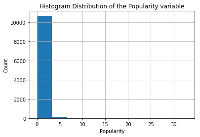

```python
# Histogram distribution of the popularity column
df.popularity.hist()
plt.xlabel('Popularity')
plt.ylabel('Count')
plt.title('Histogram Distribution of the Popularity variable');
```

The histogram is right-skewed. From the plot above, most of the movies have a low popularity score. Let's investigate further.

```python
# print out the maximum, minimum and median popularity score
print('The maximum popularity score is', df.popularity.max())
print('The minimum popularity score is', df.popularity.min())
print("The median popularity score is", df.popularity.median())

# print out the total number of movies lower than a popularity score of 1
df[df.popularity > 1]['popularity'].count()
```

```
The maximum popularity score is 32.985763
The minimum popularity score is 6.500000000000001e-05
The median popularity score is 0.383831
```

```
1756
```

Out of a total of 10865, only 1756 movies have a popularity score greater than 1.

#### Budget variable

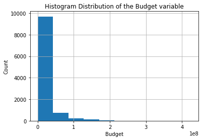

```python
# Histogram distribution of the budget column
df.budget.hist()
plt.xlabel('Budget')
plt.ylabel('Count')
plt.title('Histogram Distribution of the Budget variable');
```

The histogram distribution for the `budget` variable is right-screwed. Most of the movies in the dataset seem to have a lower budget. Let's investigate further.

```python
# print out the maximum, minimum and median budget
print('The maximum budget is', df.budget.max())
print('The minimum budget is', df.budget.min())
print("The median budget is", df.budget.median())

# print out the total number of movies lower than the median budget
df[df.budget > df.budget.median()]['budget'].count()
```

```
The maximum budget is 425000000
The minimum budget is 0
The median budget is 0.0
```

```
5169
```

Out of `10865`, `5169` movies have a budget that is higher than the median budget of 0.

It's weird that some movies have a budget of 0. Let investigate further to find out how many movies have a budget of 0.

```python
# view movies with a budget of zero
df.query('budget == "0"')
```

|  | popularity | budget | revenue | original_title | runtime | vote_count | vote_average | release_year | budget_adj | revenue_adj |
| --- | --- | --- | --- | --- | --- | --- | --- | --- | --- | --- |
| 30 | 3.927333 | 0 | 29355203 | Mr. Holmes | 103 | 425 | 6.4 | 2015 | 0.0 | 2.700677e+07 |
| 36 | 3.358321 | 0 | 22354572 | Solace | 101 | 474 | 6.2 | 2015 | 0.0 | 2.056620e+07 |
| 72 | 2.272044 | 0 | 45895 | Beyond the Reach | 95 | 81 | 5.5 | 2015 | 0.0 | 4.222338e+04 |
| 74 | 2.165433 | 0 | 0 | Mythica: The Darkspore | 108 | 27 | 5.1 | 2015 | 0.0 | 0.000000e+00 |
| 75 | 2.141506 | 0 | 0 | Me and Earl and the Dying Girl | 105 | 569 | 7.7 | 2015 | 0.0 | 0.000000e+00 |
| 88 | 1.959765 | 0 | 2000000 | Equals | 101 | 135 | 5.6 | 2015 | 0.0 | 1.839999e+06 |
| 92 | 1.876037 | 0 | 0 | Mythica: The Necromancer | 0 | 11 | 5.4 | 2015 | 0.0 | 0.000000e+00 |
| 95 | 1.841779 | 0 | 233755553 | Alvin and the Chipmunks: The Road Chip | 92 | 278 | 5.7 | 2015 | 0.0 | 2.150550e+08 |
| 100 | 1.724712 | 0 | 0 | Frozen Fever | 8 | 475 | 7.0 | 2015 | 0.0 | 0.000000e+00 |
| 101 | 1.661789 | 0 | 0 | High-Rise | 119 | 161 | 5.4 | 2015 | 0.0 | 0.000000e+00 |
| 103 | 1.646664 | 0 | 0 | Spooks: The Greater Good | 104 | 114 | 5.6 | 2015 | 0.0 | 0.000000e+00 |
| 116 | 1.380320 | 0 | 0 | The Scorpion King: The Lost Throne | 105 | 22 | 4.5 | 2015 | 0.0 | 0.000000e+00 |
| 119 | 1.360827 | 0 | 5189646 | Absolutely Anything | 85 | 199 | 5.8 | 2015 | 0.0 | 4.774472e+06 |
| 122 | 1.342839 | 0 | 0 | Everly | 90 | 169 | 5.1 | 2015 | 0.0 | 0.000000e+00 |
| 125 | 1.329702 | 0 | 229094 | Slow West | 84 | 229 | 6.6 | 2015 | 0.0 | 2.107664e+05 |
| 128 | 1.293140 | 0 | 2500431 | Mistress America | 84 | 132 | 6.4 | 2015 | 0.0 | 2.300396e+06 |
| 130 | 1.284541 | 0 | 4719695 | True Story | 100 | 354 | 6.0 | 2015 | 0.0 | 4.342117e+06 |
| 132 | 1.253580 | 0 | 59700000 | Shaun the Sheep Movie | 85 | 340 | 6.9 | 2015 | 0.0 | 5.492398e+07 |
| 134 | 1.245224 | 0 | 1702433 | A Perfect Day | 106 | 102 | 6.3 | 2015 | 0.0 | 1.566238e+06 |
| 139 | 1.161812 | 0 | 118483 | Z for Zachariah | 97 | 181 | 5.5 | 2015 | 0.0 | 1.090043e+05 |
| 140 | 1.144808 | 0 | 0 | Dragonheart 3: The Sorcerer's Curse | 97 | 59 | 4.5 | 2015 | 0.0 | 0.000000e+00 |
| 143 | 1.128081 | 0 | 0 | Brothers of the Wind | 98 | 11 | 7.5 | 2015 | 0.0 | 0.000000e+00 |
| 146 | 1.065888 | 0 | 17671101 | Regression | 106 | 310 | 5.2 | 2015 | 0.0 | 1.625741e+07 |
| 147 | 1.063055 | 0 | 0 | Pawn Sacrifice | 114 | 148 | 6.6 | 2015 | 0.0 | 0.000000e+00 |
| 148 | 1.046518 | 0 | 11472454 | The Man Who Knew Infinity | 108 | 104 | 7.1 | 2015 | 0.0 | 1.055465e+07 |
| 151 | 1.036825 | 0 | 0 | Pay the Ghost | 94 | 114 | 5.3 | 2015 | 0.0 | 0.000000e+00 |
| 152 | 1.027620 | 0 | 0 | The Voices | 101 | 371 | 6.0 | 2015 | 0.0 | 0.000000e+00 |
| 153 | 1.021441 | 0 | 3643591 | Last Knights | 115 | 237 | 6.3 | 2015 | 0.0 | 3.352102e+06 |
| 158 | 0.953647 | 0 | 0 | Miss You Already | 112 | 139 | 7.2 | 2015 | 0.0 | 0.000000e+00 |
| 161 | 0.938432 | 0 | 1936524 | A Bigger Splash | 120 | 69 | 5.8 | 2015 | 0.0 | 1.781601e+06 |
| ... | ... | ... | ... | ... | ... | ... | ... | ... | ... | ... |
| 10830 | 0.380321 | 0 | 0 | Cul-de-sac | 113 | 18 | 6.7 | 1966 | 0.0 | 0.000000e+00 |
| 10831 | 0.529721 | 0 | 0 | The Fortune Cookie | 125 | 17 | 6.4 | 1966 | 0.0 | 0.000000e+00 |
| 10833 | 0.737730 | 0 | 0 | How to Steal a Million | 123 | 67 | 7.3 | 1966 | 0.0 | 0.000000e+00 |
| 10834 | 0.310688 | 0 | 0 | Return of the Seven | 95 | 14 | 5.1 | 1966 | 0.0 | 0.000000e+00 |
| 10836 | 0.239435 | 0 | 0 | Walk Don't Run | 114 | 11 | 5.8 | 1966 | 0.0 | 0.000000e+00 |
| 10837 | 0.291704 | 0 | 0 | The Blue Max | 156 | 12 | 5.5 | 1966 | 0.0 | 0.000000e+00 |
| 10838 | 0.151845 | 0 | 0 | The Professionals | 117 | 21 | 6.0 | 1966 | 0.0 | 0.000000e+00 |
| 10839 | 0.276133 | 0 | 0 | It's the Great Pumpkin, Charlie Brown | 25 | 49 | 7.2 | 1966 | 0.0 | 0.000000e+00 |
| 10840 | 0.102530 | 0 | 0 | Funeral in Berlin | 102 | 13 | 5.7 | 1966 | 0.0 | 0.000000e+00 |
| 10842 | 0.253437 | 0 | 0 | Winnie the Pooh and the Honey Tree | 25 | 12 | 7.9 | 1966 | 0.0 | 0.000000e+00 |
| 10843 | 0.252399 | 0 | 0 | Khartoum | 134 | 12 | 5.8 | 1966 | 0.0 | 0.000000e+00 |
| 10844 | 0.236098 | 0 | 0 | Our Man Flint | 108 | 13 | 5.6 | 1966 | 0.0 | 0.000000e+00 |
| 10845 | 0.230873 | 0 | 0 | Carry On Cowboy | 93 | 15 | 5.9 | 1966 | 0.0 | 0.000000e+00 |
| 10846 | 0.212716 | 0 | 0 | Dracula: Prince of Darkness | 90 | 16 | 5.7 | 1966 | 0.0 | 0.000000e+00 |
| 10847 | 0.034555 | 0 | 0 | Island of Terror | 89 | 13 | 5.3 | 1966 | 0.0 | 0.000000e+00 |
| 10849 | 0.206537 | 0 | 0 | Gambit | 109 | 14 | 6.1 | 1966 | 0.0 | 0.000000e+00 |
| 10850 | 0.202473 | 0 | 0 | Harper | 121 | 14 | 6.0 | 1966 | 0.0 | 0.000000e+00 |
| 10851 | 0.342791 | 0 | 0 | Born Free | 95 | 15 | 6.6 | 1966 | 0.0 | 0.000000e+00 |
| 10852 | 0.227220 | 0 | 0 | A Big Hand for the Little Lady | 95 | 11 | 6.0 | 1966 | 0.0 | 0.000000e+00 |
| 10853 | 0.163592 | 0 | 0 | Alfie | 114 | 26 | 6.2 | 1966 | 0.0 | 0.000000e+00 |
| 10854 | 0.146402 | 0 | 0 | The Chase | 135 | 17 | 6.0 | 1966 | 0.0 | 0.000000e+00 |
| 10856 | 0.140934 | 0 | 0 | The Ugly Dachshund | 93 | 14 | 5.7 | 1966 | 0.0 | 0.000000e+00 |
| 10857 | 0.131378 | 0 | 0 | Nevada Smith | 128 | 10 | 5.9 | 1966 | 0.0 | 0.000000e+00 |
| 10858 | 0.317824 | 0 | 0 | The Russians Are Coming, The Russians Are Coming | 126 | 11 | 5.5 | 1966 | 0.0 | 0.000000e+00 |
| 10859 | 0.089072 | 0 | 0 | Seconds | 100 | 22 | 6.6 | 1966 | 0.0 | 0.000000e+00 |
| 10860 | 0.087034 | 0 | 0 | Carry On Screaming! | 87 | 13 | 7.0 | 1966 | 0.0 | 0.000000e+00 |
| 10861 | 0.080598 | 0 | 0 | The Endless Summer | 95 | 11 | 7.4 | 1966 | 0.0 | 0.000000e+00 |
| 10862 | 0.065543 | 0 | 0 | Grand Prix | 176 | 20 | 5.7 | 1966 | 0.0 | 0.000000e+00 |
| 10863 | 0.065141 | 0 | 0 | Beregis Avtomobilya | 94 | 11 | 6.5 | 1966 | 0.0 | 0.000000e+00 |
| 10864 | 0.064317 | 0 | 0 | What's Up, Tiger Lily? | 80 | 22 | 5.4 | 1966 | 0.0 | 0.000000e+00 |

5696 rows × 10 columns

```python
# count the number of movies with a budget of zero
df.query('budget == "0"')['budget'].count()
```

```
5696
```

There are 5696 movies with a budget of `zero`. This is strange. It's either these movies are no-budget movies, or there are missing values and unknown values replaced with 0.

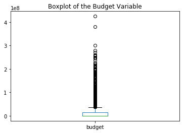

```python
df.budget.plot(kind='box')
plt.title('Boxplot of the Budget Variable');
```

#### Revenue Variable

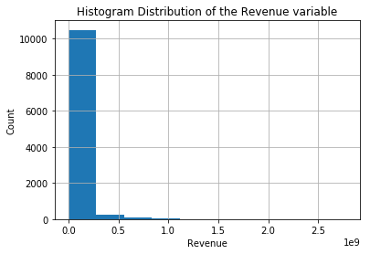

```python
# Histogram distribution of the revenue column
df.revenue.hist()
plt.xlabel('Revenue')
plt.ylabel('Count')
plt.title('Histogram Distribution of the Revenue variable');
```

The histogram distribution for the `revenue` variable is right-screwed. Most of the movies in the dataset seem to have a lower revenue. Let's investigate further.

```python
# print out the maximum, minimum and median revenue
print('The maximum revenue is', df.revenue.max())
print('The minimum revenue is', df.revenue.min())
print("The median revenue is", df.revenue.median())

# print out the total number of movies lower than the median revenue
df[df.revenue > df.revenue.median()]['revenue'].count()
```

```
The maximum revenue is 2781505847
The minimum revenue is 0
The median revenue is 0.0
```

```
4849
```

Out of `10865`, `4849` movies have a revenue that is higher than the `median revenue of 0`.

Just like the `budget` variable, some movies have a `revenue` of 0. Let investigate further to find out how many movies have a revenue of 0.

```python
# view movies with a revenue of zero
df.query('revenue == "0"')
```

|  | popularity | budget | revenue | original_title | runtime | vote_count | vote_average | release_year | budget_adj | revenue_adj |
| --- | --- | --- | --- | --- | --- | --- | --- | --- | --- | --- |
| 48 | 2.932340 | 30000000 | 0 | Wild Card | 92 | 481 | 5.3 | 2015 | 2.759999e+07 | 0.0 |
| 67 | 2.331636 | 20000000 | 0 | Survivor | 96 | 280 | 5.4 | 2015 | 1.839999e+07 | 0.0 |
| 74 | 2.165433 | 0 | 0 | Mythica: The Darkspore | 108 | 27 | 5.1 | 2015 | 0.000000e+00 | 0.0 |
| 75 | 2.141506 | 0 | 0 | Me and Earl and the Dying Girl | 105 | 569 | 7.7 | 2015 | 0.000000e+00 | 0.0 |
| 92 | 1.876037 | 0 | 0 | Mythica: The Necromancer | 0 | 11 | 5.4 | 2015 | 0.000000e+00 | 0.0 |
| 93 | 1.872696 | 10000000 | 0 | Vice | 96 | 181 | 4.1 | 2015 | 9.199996e+06 | 0.0 |
| 100 | 1.724712 | 0 | 0 | Frozen Fever | 8 | 475 | 7.0 | 2015 | 0.000000e+00 | 0.0 |
| 101 | 1.661789 | 0 | 0 | High-Rise | 119 | 161 | 5.4 | 2015 | 0.000000e+00 | 0.0 |
| 103 | 1.646664 | 0 | 0 | Spooks: The Greater Good | 104 | 114 | 5.6 | 2015 | 0.000000e+00 | 0.0 |
| 116 | 1.380320 | 0 | 0 | The Scorpion King: The Lost Throne | 105 | 22 | 4.5 | 2015 | 0.000000e+00 | 0.0 |
| 122 | 1.342839 | 0 | 0 | Everly | 90 | 169 | 5.1 | 2015 | 0.000000e+00 | 0.0 |
| 133 | 1.251681 | 11000000 | 0 | Louder Than Bombs | 109 | 43 | 6.3 | 2015 | 1.012000e+07 | 0.0 |
| 140 | 1.144808 | 0 | 0 | Dragonheart 3: The Sorcerer's Curse | 97 | 59 | 4.5 | 2015 | 0.000000e+00 | 0.0 |
| 143 | 1.128081 | 0 | 0 | Brothers of the Wind | 98 | 11 | 7.5 | 2015 | 0.000000e+00 | 0.0 |
| 145 | 1.073349 | 1800000 | 0 | Bone Tomahawk | 132 | 220 | 6.3 | 2015 | 1.655999e+06 | 0.0 |
| 147 | 1.063055 | 0 | 0 | Pawn Sacrifice | 114 | 148 | 6.6 | 2015 | 0.000000e+00 | 0.0 |
| 149 | 1.041922 | 20000000 | 0 | Momentum | 96 | 100 | 5.8 | 2015 | 1.839999e+07 | 0.0 |
| 151 | 1.036825 | 0 | 0 | Pay the Ghost | 94 | 114 | 5.3 | 2015 | 0.000000e+00 | 0.0 |
| 152 | 1.027620 | 0 | 0 | The Voices | 101 | 371 | 6.0 | 2015 | 0.000000e+00 | 0.0 |
| 154 | 1.008474 | 12000000 | 0 | Il racconto dei racconti | 125 | 211 | 5.7 | 2015 | 1.104000e+07 | 0.0 |
| 156 | 0.973316 | 15000000 | 0 | Queen of the Desert | 128 | 30 | 6.0 | 2015 | 1.379999e+07 | 0.0 |
| 158 | 0.953647 | 0 | 0 | Miss You Already | 112 | 139 | 7.2 | 2015 | 0.000000e+00 | 0.0 |
| 159 | 0.953046 | 630019 | 0 | Kung Fury | 31 | 487 | 7.7 | 2015 | 5.796172e+05 | 0.0 |
| 164 | 0.917040 | 0 | 0 | Kidnapping Mr. Heineken | 95 | 131 | 5.8 | 2015 | 0.000000e+00 | 0.0 |
| 165 | 0.913085 | 60000000 | 0 | The Ridiculous 6 | 119 | 252 | 4.8 | 2015 | 5.519998e+07 | 0.0 |
| 166 | 0.906860 | 0 | 0 | Kill Me Three Times | 90 | 96 | 5.1 | 2015 | 0.000000e+00 | 0.0 |
| 169 | 0.894477 | 0 | 0 | 45 Years | 95 | 167 | 6.0 | 2015 | 0.000000e+00 | 0.0 |
| 174 | 0.861179 | 0 | 0 | Jenny's Wedding | 94 | 92 | 5.2 | 2015 | 0.000000e+00 | 0.0 |
| 175 | 0.848748 | 0 | 0 | Descendants | 112 | 262 | 6.7 | 2015 | 0.000000e+00 | 0.0 |
| 176 | 0.843174 | 0 | 0 | Tumbledown | 105 | 22 | 6.6 | 2015 | 0.000000e+00 | 0.0 |
| ... | ... | ... | ... | ... | ... | ... | ... | ... | ... | ... |
| 10834 | 0.310688 | 0 | 0 | Return of the Seven | 95 | 14 | 5.1 | 1966 | 0.000000e+00 | 0.0 |
| 10836 | 0.239435 | 0 | 0 | Walk Don't Run | 114 | 11 | 5.8 | 1966 | 0.000000e+00 | 0.0 |
| 10837 | 0.291704 | 0 | 0 | The Blue Max | 156 | 12 | 5.5 | 1966 | 0.000000e+00 | 0.0 |
| 10838 | 0.151845 | 0 | 0 | The Professionals | 117 | 21 | 6.0 | 1966 | 0.000000e+00 | 0.0 |
| 10839 | 0.276133 | 0 | 0 | It's the Great Pumpkin, Charlie Brown | 25 | 49 | 7.2 | 1966 | 0.000000e+00 | 0.0 |
| 10840 | 0.102530 | 0 | 0 | Funeral in Berlin | 102 | 13 | 5.7 | 1966 | 0.000000e+00 | 0.0 |
| 10841 | 0.264925 | 75000 | 0 | The Shooting | 82 | 12 | 5.5 | 1966 | 5.038511e+05 | 0.0 |
| 10842 | 0.253437 | 0 | 0 | Winnie the Pooh and the Honey Tree | 25 | 12 | 7.9 | 1966 | 0.000000e+00 | 0.0 |
| 10843 | 0.252399 | 0 | 0 | Khartoum | 134 | 12 | 5.8 | 1966 | 0.000000e+00 | 0.0 |
| 10844 | 0.236098 | 0 | 0 | Our Man Flint | 108 | 13 | 5.6 | 1966 | 0.000000e+00 | 0.0 |
| 10845 | 0.230873 | 0 | 0 | Carry On Cowboy | 93 | 15 | 5.9 | 1966 | 0.000000e+00 | 0.0 |
| 10846 | 0.212716 | 0 | 0 | Dracula: Prince of Darkness | 90 | 16 | 5.7 | 1966 | 0.000000e+00 | 0.0 |
| 10847 | 0.034555 | 0 | 0 | Island of Terror | 89 | 13 | 5.3 | 1966 | 0.000000e+00 | 0.0 |
| 10849 | 0.206537 | 0 | 0 | Gambit | 109 | 14 | 6.1 | 1966 | 0.000000e+00 | 0.0 |
| 10850 | 0.202473 | 0 | 0 | Harper | 121 | 14 | 6.0 | 1966 | 0.000000e+00 | 0.0 |
| 10851 | 0.342791 | 0 | 0 | Born Free | 95 | 15 | 6.6 | 1966 | 0.000000e+00 | 0.0 |
| 10852 | 0.227220 | 0 | 0 | A Big Hand for the Little Lady | 95 | 11 | 6.0 | 1966 | 0.000000e+00 | 0.0 |
| 10853 | 0.163592 | 0 | 0 | Alfie | 114 | 26 | 6.2 | 1966 | 0.000000e+00 | 0.0 |
| 10854 | 0.146402 | 0 | 0 | The Chase | 135 | 17 | 6.0 | 1966 | 0.000000e+00 | 0.0 |
| 10855 | 0.141026 | 700000 | 0 | The Ghost & Mr. Chicken | 90 | 14 | 6.1 | 1966 | 4.702610e+06 | 0.0 |
| 10856 | 0.140934 | 0 | 0 | The Ugly Dachshund | 93 | 14 | 5.7 | 1966 | 0.000000e+00 | 0.0 |
| 10857 | 0.131378 | 0 | 0 | Nevada Smith | 128 | 10 | 5.9 | 1966 | 0.000000e+00 | 0.0 |
| 10858 | 0.317824 | 0 | 0 | The Russians Are Coming, The Russians Are Coming | 126 | 11 | 5.5 | 1966 | 0.000000e+00 | 0.0 |
| 10859 | 0.089072 | 0 | 0 | Seconds | 100 | 22 | 6.6 | 1966 | 0.000000e+00 | 0.0 |
| 10860 | 0.087034 | 0 | 0 | Carry On Screaming! | 87 | 13 | 7.0 | 1966 | 0.000000e+00 | 0.0 |
| 10861 | 0.080598 | 0 | 0 | The Endless Summer | 95 | 11 | 7.4 | 1966 | 0.000000e+00 | 0.0 |
| 10862 | 0.065543 | 0 | 0 | Grand Prix | 176 | 20 | 5.7 | 1966 | 0.000000e+00 | 0.0 |
| 10863 | 0.065141 | 0 | 0 | Beregis Avtomobilya | 94 | 11 | 6.5 | 1966 | 0.000000e+00 | 0.0 |
| 10864 | 0.064317 | 0 | 0 | What's Up, Tiger Lily? | 80 | 22 | 5.4 | 1966 | 0.000000e+00 | 0.0 |
| 10865 | 0.035919 | 19000 | 0 | Manos: The Hands of Fate | 74 | 15 | 1.5 | 1966 | 1.276423e+05 | 0.0 |

6016 rows × 10 columns

```python
# count the number of movies with a revenue of zero
df.query('revenue == "0"')['revenue'].count()
```

```
6016
```

There are 6016 movies with a `revenue` of `zero`. This is strange. It's either these movies are did not generate any revenue, or there were missing values and unknown values that were replaced with 0.

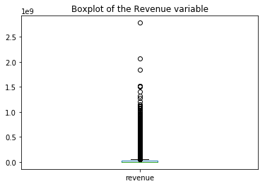

```python
df.revenue.plot(kind='box')
plt.title('Boxplot of the Revenue variable');
```

#### Runtime Variable

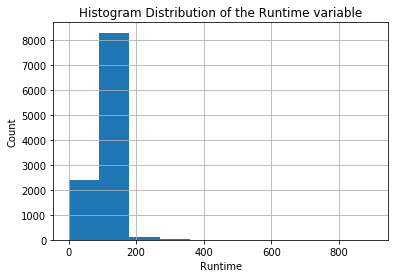

```python
# Histogram distribution of the runtime column
df.runtime.hist()
plt.xlabel('Runtime')
plt.ylabel('Count')
plt.title('Histogram Distribution of the Runtime variable');
```

From the plot above, most of the movies in the dataset have a runtime less than 200 minutes. Let's investigate further.

```python
# print out the maximum, minimum and median runtime
print('The maximum runtime is', df.runtime.max())
print('The minimum runtime is', df.runtime.min())
print("The median runtime is", df.runtime.median())

# print out the total number of movies lower than the 200 minutes runtime
df[df.runtime > 200]['runtime'].count()
```

```
The maximum runtime is 900
The minimum runtime is 0
The median runtime is 99.0
```

```
73
```

Out of `10865`, `73` movies have a runtime longer than 200 minutes.

You'll also notice that the minimum runtime is 0. This isn't right. Let investigate further to find out how many movies have a runtime of 0. The maximum runtime is 900 minutes (15 hours). This could be a data entry error. Further investigation is needed.

```python
# view movie with a runtime of 900
df.query('runtime == "900"')
```

|  | popularity | budget | revenue | original_title | runtime | vote_count | vote_average | release_year | budget_adj | revenue_adj |
| --- | --- | --- | --- | --- | --- | --- | --- | --- | --- | --- |
| 3894 | 0.006925 | 0 | 0 | The Story of Film: An Odyssey | 900 | 14 | 9.2 | 2011 | 0.0 | 0.0 |

After doing some research, I discovered that the movie `The Story of Film: An Odyssey` has a runtime of `915` minutes. This record is valid.

```python
# view movies with a runtime of zero
df.query('runtime == "0"')
```

|  | popularity | budget | revenue | original_title | runtime | vote_count | vote_average | release_year | budget_adj | revenue_adj |
| --- | --- | --- | --- | --- | --- | --- | --- | --- | --- | --- |
| 92 | 1.876037 | 0 | 0 | Mythica: The Necromancer | 0 | 11 | 5.4 | 2015 | 0.000000e+00 | 0.0 |
| 334 | 0.357654 | 0 | 0 | Ronaldo | 0 | 80 | 6.5 | 2015 | 0.000000e+00 | 0.0 |
| 410 | 0.097514 | 0 | 0 | Anarchy Parlor | 0 | 15 | 5.6 | 2015 | 0.000000e+00 | 0.0 |
| 445 | 0.218528 | 0 | 0 | The Exorcism of Molly Hartley | 0 | 52 | 5.0 | 2015 | 0.000000e+00 | 0.0 |
| 486 | 0.176744 | 0 | 0 | If There Be Thorns | 0 | 11 | 5.4 | 2015 | 0.000000e+00 | 0.0 |
| 595 | 0.028725 | 0 | 0 | Deep Dark | 0 | 11 | 4.6 | 2015 | 0.000000e+00 | 0.0 |
| 616 | 0.026797 | 0 | 0 | The Outfield | 0 | 20 | 6.6 | 2015 | 0.000000e+00 | 0.0 |
| 1241 | 0.135376 | 0 | 0 | Dance-Off | 0 | 18 | 5.7 | 2014 | 0.000000e+00 | 0.0 |
| 1289 | 0.037459 | 3250000 | 0 | Treehouse | 0 | 16 | 3.4 | 2014 | 2.993546e+06 | 0.0 |
| 1293 | 0.036904 | 0 | 0 | Tim Maia | 0 | 14 | 6.0 | 2014 | 0.000000e+00 | 0.0 |
| 1849 | 0.120350 | 0 | 0 | Spectacular! | 0 | 13 | 5.2 | 2009 | 0.000000e+00 | 0.0 |
| 2315 | 0.171615 | 0 | 0 | Listen to Your Heart | 0 | 29 | 7.3 | 2010 | 0.000000e+00 | 0.0 |
| 2370 | 0.081892 | 0 | 0 | Freshman Father | 0 | 12 | 5.8 | 2010 | 0.000000e+00 | 0.0 |
| 3329 | 0.082898 | 0 | 0 | Grande, grosso e Verdone | 0 | 35 | 5.3 | 2008 | 0.000000e+00 | 0.0 |
| 3794 | 0.183134 | 0 | 0 | Toi, moi, les autres | 0 | 17 | 5.2 | 2011 | 0.000000e+00 | 0.0 |
| 3857 | 0.095583 | 0 | 0 | Cell 213 | 0 | 13 | 5.2 | 2011 | 0.000000e+00 | 0.0 |
| 3884 | 0.045198 | 0 | 0 | eCupid | 0 | 12 | 4.6 | 2011 | 0.000000e+00 | 0.0 |
| 4063 | 0.371510 | 6000000 | 0 | Madea's Family Reunion | 0 | 49 | 5.9 | 2002 | 7.273568e+06 | 0.0 |
| 4138 | 0.035895 | 0 | 0 | A Time for Dancing | 0 | 14 | 7.5 | 2002 | 0.000000e+00 | 0.0 |
| 4829 | 0.140016 | 0 | 0 | Rags | 0 | 24 | 5.7 | 2012 | 0.000000e+00 | 0.0 |
| 4944 | 0.026459 | 0 | 0 | How to Fall in Love | 0 | 11 | 4.7 | 2012 | 0.000000e+00 | 0.0 |
| 5216 | 0.073665 | 0 | 0 | Madea's Class Reunion | 0 | 12 | 6.9 | 2003 | 0.000000e+00 | 0.0 |
| 5695 | 0.417739 | 0 | 0 | Skinwalker Ranch | 0 | 27 | 4.3 | 2013 | 0.000000e+00 | 0.0 |
| 5920 | 0.165765 | 0 | 0 | The Food Guide to Love | 0 | 12 | 5.6 | 2013 | 0.000000e+00 | 0.0 |
| 5938 | 0.147188 | 0 | 0 | Go Goa Gone | 0 | 16 | 5.3 | 2013 | 0.000000e+00 | 0.0 |
| 5992 | 0.096455 | 0 | 0 | Amiche da morire | 0 | 30 | 5.5 | 2013 | 0.000000e+00 | 0.0 |
| 6040 | 0.011798 | 0 | 0 | The Vatican Exorcisms | 0 | 10 | 4.7 | 2013 | 0.000000e+00 | 0.0 |
| 6383 | 0.371630 | 2000000 | 0 | The 12 Dogs of Christmas | 0 | 11 | 4.7 | 2005 | 2.233127e+06 | 0.0 |
| 6552 | 0.006440 | 0 | 0 | Quatre Ã©toiles | 0 | 15 | 5.9 | 2005 | 0.000000e+00 | 0.0 |
| 6934 | 0.071872 | 0 | 0 | Jean-Philippe | 0 | 26 | 5.6 | 2006 | 0.000000e+00 | 0.0 |
| 8874 | 0.069903 | 0 | 0 | Mission Kashmir | 0 | 10 | 5.7 | 2000 | 0.000000e+00 | 0.0 |

From the result above, you'll notice that all the movies with a runtime of `0`, also have a revenue of `0`.

After doing research, I discovered that most of the movies do not have a runtime of zero. For further analysis (correlation analysis) with this variable, I will have to remove the records that have a value of `0`.

```python
# count the number of movies with a budget of zero
df.query('runtime == "0"')['runtime'].count()
```

```
31
```

There are 31 movies with a runtime of `0`.

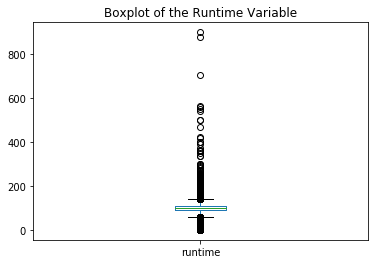

```python
# Plot a BoxPlot of the Runtime variable
df.runtime.plot(kind='box')
plt.title('Boxplot of the Runtime Variable');
```

### Vote Count Variable

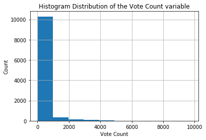

```python
# Histogram distribution of the vote_count variable
df.vote_count.hist()
plt.xlabel('Vote Count')
plt.ylabel('Count')
plt.title('Histogram Distribution of the Vote Count variable');
```

The histogram distribution of the `vote_count` variable is `right-skewed`. From the plot above, most of the movies a lower vote count. Let's investigate further.

```python
# print out the maximum, minimum and median vote_count
print('The maximum vote count is', df.vote_count.max())
print('The minimum vote count is', df.vote_count.min())
print("The median vote count is", df.vote_count.median())

# print out the total number of movies lower than 2000 vote_count
df[df.vote_count > 2000]['vote_count'].count()
```

```
The maximum vote count is 9767
The minimum vote count is 10
The median vote count is 38.0
```

```
232
```

Out of `10865`, `232` movies have a vote count higher than 2000.

The minimum vote count is 10.

### Vote Average Variable

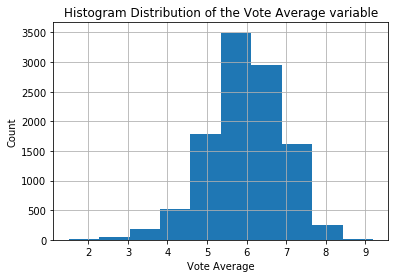

```python
# Histogram distribution of the vote_average variable
df.vote_average.hist()
plt.xlabel('Vote Average')
plt.ylabel('Count')
plt.title('Histogram Distribution of the Vote Average variable');
```

From the histogram distribution above, most of the movies have a vote average between the range of 5-7.

```python
# print out the maximum, minimum and median vote_average
print('The maximum vote average is', df.vote_average.max())
print('The minimum vote average is', df.vote_average.min())
print("The median vote average is", df.vote_average.median())

# print out the total number of movies greater than the median vote_average
df[df.vote_average > df.vote_average.median()]['vote_average'].count()
```

```
The maximum vote average is 9.2
The minimum vote average is 1.5
The median vote average is 6.0
```

```
5315
```

Out of `10865`, `5315` movies have a vote average higher than the median vote_average of 6.0.

### Release Year Variable

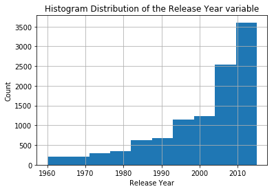

```python
# Histogram distribution of the release year variable
df.release_year.hist()
plt.xlabel('Release Year')
plt.ylabel('Count')
plt.title('Histogram Distribution of the Release Year variable');
```

The histogram distribution of the `release_year` variable is `left-skewed`. We have more movies released in the 2000s.

```python
# set the index of the dataframe to original title
df.set_index('original_title', inplace=True)
```

### Question 1: What are the top 10 movies with the highest runtime?

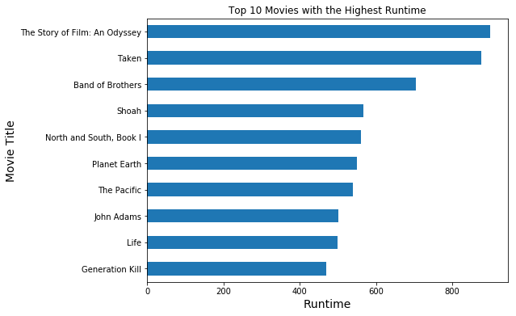

```python
# sort the data by runtime in ascending order
df_sorted_runtime = df.sort_values(by='runtime')

# filter the dataframe to get only the runtime
# and get the last ten records after sorting
df_sorted_runtime = df_sorted_runtime[['runtime']].iloc[-10:]

# plot a bar chart using pandas
df_sorted_runtime.plot(kind='barh', figsize=(8,6))
# remove legend
plt.legend().remove()
plt.ylabel('Movie Title', fontsize=14)
plt.xlabel('Runtime', fontsize=14)
plt.title('Top 10 Movies with the Highest Runtime');
```

The top 10 movies with the highest runtime are:

- The Story of Film: An Odyssey,
- Taken,
- Band of Brothers,
- Shoah,
- North and South, Book I,
- Planet Earth,
- The Pacific,
- John Adams,
- Life,
- Generation Kill

### Question 2: What are the top 10 movies with the highest revenue?

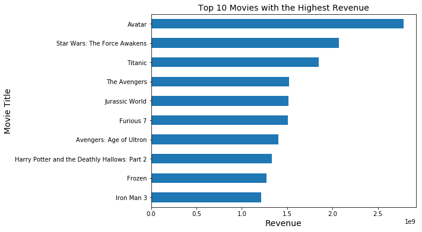

```python
# sort the data by revenue in ascending order
df_sorted_revenue = df.sort_values(by='revenue')

# filter the dataframe to get only the revenue
# and get the last ten records after sorting
df_sorted_revenue = df_sorted_revenue[['revenue']].iloc[-10:]

# # plot a bar chart using matplotlib
# plt.figure(figsize=(8, 6))  # set figure size
# plt.barh(df_sorted_revenue.index ,'revenue', data=df_sorted_revenue)
# plt.ylabel('Movie Title', fontsize=14)
# plt.xlabel('Revenue', fontsize=14)
# plt.title('Top 10 Movies with the Highest Revenue');

# plot a bar chart using pandas
df_sorted_revenue.plot(kind='barh', figsize=(8,6))
# remove legend
plt.legend().remove()
plt.ylabel('Movie Title', fontsize=14)
plt.xlabel('Revenue', fontsize=14)
plt.title('Top 10 Movies with the Highest Revenue', size=14);
```

The top 10 movies with the highest revenue are:

- Avatar,
- Star Wars: The Force Awakens,
- Titanic,
- The Avengers,
- Jurassic World,
- Furious 7,
- Avengers: Age of Ultron,
- Harry Potter and the Deathly Hallows: Part 2,
- Frozen,
- Iron Man 3

### Question 3: What are the top 10 movies with the highest budget?

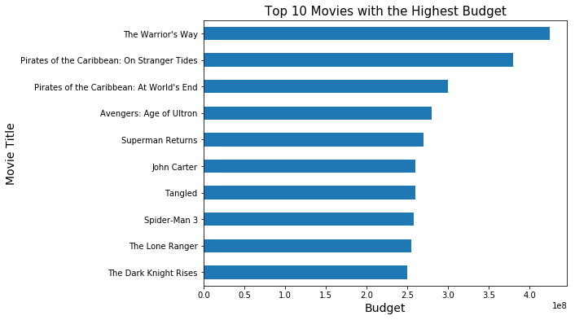

```python
# sort the data by budget in ascending order
df_sorted_budget = df.sort_values(by='budget')

# filter the dataframe to get only the budget
# and get the last ten records after sorting
df_sorted_budget = df_sorted_budget[['budget']].iloc[-10:]

# plot a bar chart
df_sorted_budget.plot(kind='barh', figsize=(8, 6))
plt.legend().remove()
plt.ylabel('Movie Title', fontsize=14)
plt.xlabel('Budget', fontsize=14)
plt.title('Top 10 Movies with the Highest Budget', size=15);
```

### Question 4: What are the most popular movies based on popularity score?

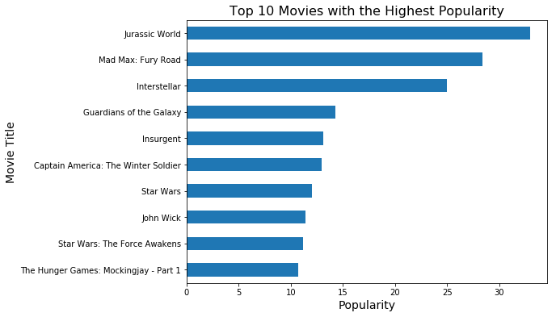

```python
# sort the data by popularity in ascending order
df_sorted_popularity = df.sort_values(by='popularity')

# filter the dataframe to get only the original title and popularity
# and get the last ten records after sorting
df_sorted_popularity = df_sorted_popularity[['popularity']].iloc[-10:]

# plot a bar chart
df_sorted_popularity.plot(kind='barh', figsize=(8, 6))
plt.legend().remove()
plt.ylabel('Movie Title', fontsize=14)
plt.xlabel('Popularity', fontsize=14)
plt.title('Top 10 Movies with the Highest Popularity', size=16);
```

Based on the popularity score, the most popular movies are:

- Jurassic World,
- Mad Max: Fury Road,
- Interstellar,
- Guardians of the Galaxy,
- Insurgent,
- Captain America: The Winter Soldier,
- Star Wars,
- John Wick,
- Star Wars: The Force Awakens,
- The Hunger Games: Mockingjay - Part 1

### Question 5: In what year was the highest total revenue generated?

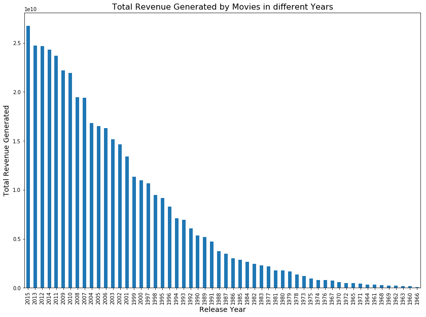

```python
release_year_revenues = df.groupby('release_year').revenue.sum().sort_values(ascending=False)
release_year_revenues.plot(kind='bar', figsize=(14,10))
plt.xlabel('Release Year', fontsize=14)
plt.ylabel('Total Revenue Generated', fontsize=14)
plt.title('Total Revenue Generated by Movies in different Years', size=16);
```

In the year 2015, the highest revenue was generated ($26,762,450,518). The lowest revenue was generated in the year 1966.

Let's compare this with the total number of movies released in each year

### Question 6: What is the total number of movies produced each year?

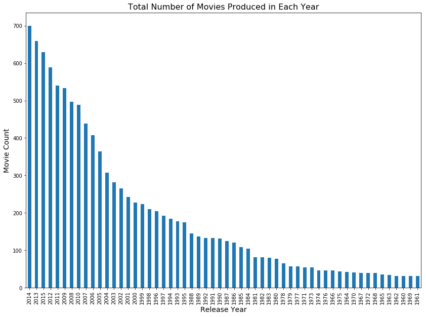

```python
# check the number of movies release each year
movies_yearly_count = df.release_year.value_counts()

movies_yearly_count.plot(kind='bar', figsize=(14,10))
plt.xlabel('Release Year', fontsize=14)
plt.ylabel('Movie Count', fontsize=14)
plt.title('Total Number of Movies Produced in Each Year', size=16);
```

700 movies were released in 2014, while 629 movies were released in 2015. Yet 2015 is the year with the highest revenue.

31 movies were released in 1961

### Question 7: Which year has the highest total budget?

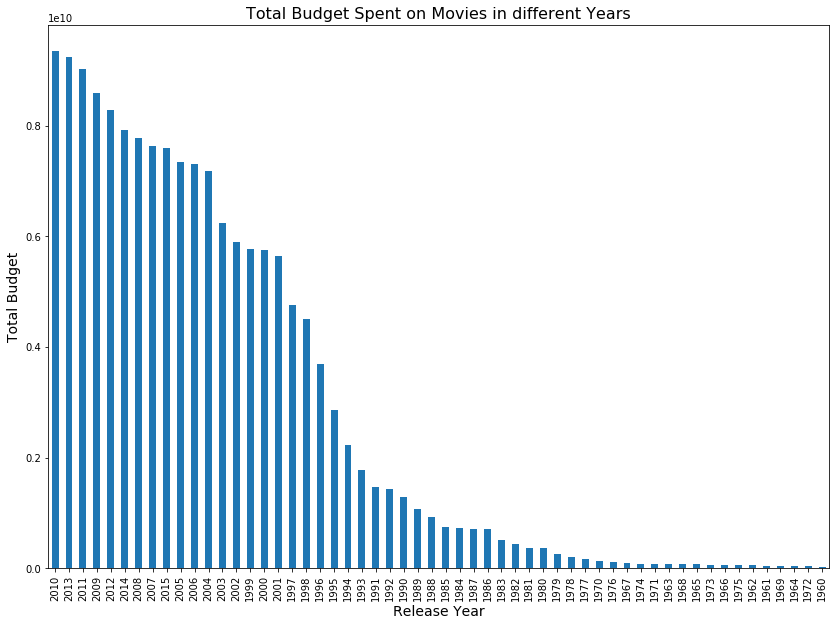

```python
release_year_budget = df.groupby('release_year').budget.sum().sort_values(ascending=False)
release_year_budget.plot(kind='bar', figsize=(14,10))
plt.xlabel('Release Year', fontsize=14)
plt.ylabel('Total Budget', fontsize=14)
plt.title('Total Budget Spent on Movies in different Years', size=16);
```

Compared to other year, a lot of money was budgetted for movies in the year 2010 ($9,355,001,006).

### Question 8: Do movies with long runtime cost more money to make? Is there a correlation between runtime and budget?

Before plotting a scatter plot to compare the relationship between budget, revenue and runtime, we first remove all the 0 values in the three columns.

```python
df.shape
```

```
(10865, 9)
```

```python
# create a copy of the dataframe
df_copy = df.copy()

# replace 0 values in the runtime, revenue, & budge columns with NaN
df_copy.runtime.replace(0, np.nan, inplace=True)
df_copy.budget.replace(0, np.nan, inplace=True)
df_copy.revenue.replace(0, np.nan, inplace=True)

# remove all missing values in the df_copy
df_copy.dropna(axis=0, inplace=True)
df_copy.shape
```

```
(3854, 9)
```

Originally, we had 10865 records. After removing the zero values in the runtime, budget, and revenue columns, we now have 3854 records.

```
The correlation between runtime and budget variable is 0.260977101404115
```

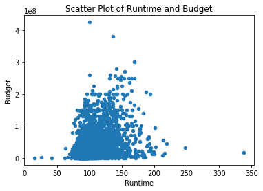

```python
# check correlation between runtime and budget columns
budget_corr = df_copy.runtime.corr(df_copy.budget)
print("The correlation between runtime and budget variable is", budget_corr)

# plot scatter plot of runtime and budget columns
df_copy.plot(x='runtime', y='budget', kind='scatter')
plt.xlabel('Runtime')
plt.ylabel('Budget')
plt.title('Scatter Plot of Runtime and Budget');
```

There is a weak correlation between the runtime and the budget column. This could mean the runtime of a movie doesn't depend on the budget of the movie. Further investigation has to be done.

### Question 9: Do movies with long runtime have higher revenue? Is there a correlation between runtime and revenue?

```
The correlation between runtime and revenue variable is 0.2502983488743395
```

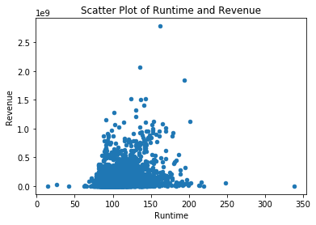

```python
# check correlation between runtime and revenue columns
revenue_corr = df_copy.runtime.corr(df_copy.revenue)
print("The correlation between runtime and revenue variable is", revenue_corr)

# plot scatter plot of runtime and revenue columns
df_copy.plot(x='runtime', y='revenue', kind='scatter')
plt.xlabel('Runtime')
plt.ylabel('Revenue')
plt.title('Scatter Plot of Runtime and Revenue');
```

There is also a weak correlation between the runtime and the revenue column. This could mean the runtime of a movie does not affect the revenue the movie generates.

### Question 10: Do movies with a high budget generate high revenue? Is there a correlation between budget and revenue?

```
The correlation between budget and revenue variable is 0.6885561524636742
```

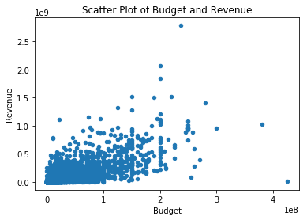

```python
# check correlation between budget and revenue columns
revenue_budget_corr = df_copy.budget.corr(df_copy.revenue)
print("The correlation between budget and revenue variable is", revenue_budget_corr)

# plot scatter plot of budget and revenue columns
df_copy.plot(x='budget', y='revenue', kind='scatter')
plt.xlabel('Budget')
plt.ylabel('Revenue')
plt.title('Scatter Plot of Budget and Revenue');
```

There is a positive correlation between the budget and the revenue. This could mean that movies with a higher budget tend to generate more revenue. Further investigation has to be done.

### Question 11: Is there a correlation between revenue and revenue_adj?

```
The correlation between revenue_adj and revenue variable is 0.9008824624476254
```

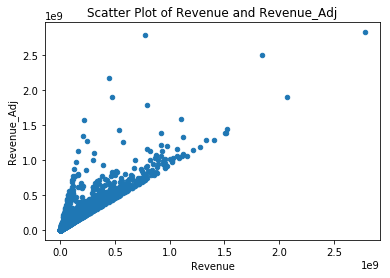

```python
# check correlation between revenue_adj and revenue columns
revenue_adj_corr = df_copy.revenue_adj.corr(df_copy.revenue)
print("The correlation between revenue_adj and revenue variable is", revenue_adj_corr)

# plot scatter plot of revenue_adj and revenue columns
df_copy.plot(x='revenue', y='revenue_adj', kind='scatter')
plt.xlabel('Revenue')
plt.ylabel('Revenue_Adj')
plt.title('Scatter Plot of Revenue and Revenue_Adj');
```

There is a strong positive relationship between the revenue variable and the revenue_adj variable

### Question 12: Is there a correlation between budget and budget_adj?

```
The correlation between budget_adj and budget variable is 0.9585196816249248
```

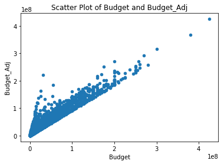

```python
# check correlation between budget_adj and budget columns
budget_adj_corr = df_copy.budget_adj.corr(df_copy.budget)
print("The correlation between budget_adj and budget variable is", budget_adj_corr)

# plot scatter plot of budget_adj and budget columns
df_copy.plot(x='budget', y='budget_adj', kind='scatter')
plt.xlabel('Budget')
plt.ylabel('Budget_Adj')
plt.title('Scatter Plot of Budget and Budget_Adj');
```

There is also a strong positive relationship between the budget variable and the budget_adj variable

### Question 13: Is there a relationship between vote count and vote average?

```python
# Check if there is any 0 value in the vote_average column
display(df.query('vote_average == 0').vote_average.count())

# Check if there is any 0 value in the vote_count column
df.query('vote_count == 0').vote_count.count()
```

```
0
```

```
0
```

Since there are no 0 values in the `vote_average` and `vote_count` columns, I'll use the original dataset `df` instead of `df_copy` to create a scatter plot.

```
The correlation between vote_count and vote_average variable is 0.2538178660024551
```

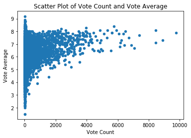

```python
# check correlation between vote count and vote average columns
vote_corr = df.vote_count.corr(df.vote_average)
print("The correlation between vote_count and vote_average variable is", vote_corr)

# plot scatter plot of budget_adj and budget columns
df.plot(x='vote_count', y='vote_average', kind='scatter')
plt.xlabel('Vote Count')
plt.ylabel('Vote Average')
plt.title('Scatter Plot of Vote Count and Vote Average');
```

There is a weak relationship between `vote_count` and `vote_average`. The correlation between the two variables in `0.25`.

### Question 14: Are movies with high vote counts more popular? (Compare vote count and popularity score)

```
The correlation between vote_count and popularity variable is 0.8008284932673039
```

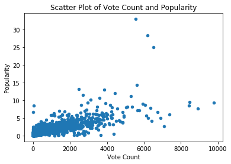

```python
# check correlation between vote_count and popularity columns
popularity_corr = df.vote_count.corr(df.popularity)
print("The correlation between vote_count and popularity variable is", popularity_corr)

# plot scatter plot of budget_adj and budget columns
df.plot(x='vote_count', y='popularity', kind='scatter')
plt.xlabel('Vote Count')
plt.ylabel('Popularity')
plt.title('Scatter Plot of Vote Count and Popularity');
```

There is a high positive correlation between the `vote count` and `popularity`. The correlation coefficient is `0.80`

### Question 15: Do popular movies generate more revenue?

```
The correlation between popularity and revenue variable is 0.615534654554661
```

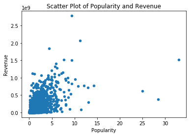

```python
# check correlation between popularity and revenue columns
revenue_corr = df_copy.revenue.corr(df_copy.popularity)
print("The correlation between popularity and revenue variable is", revenue_corr)

# plot scatter plot of popularity and revenue columns
df_copy.plot(x='popularity', y='revenue', kind='scatter')
plt.xlabel('Popularity')
plt.ylabel('Revenue')
plt.title('Scatter Plot of Popularity and Revenue');
```

There is a positive correlation between the `popularity` of a movie and the `revenue` it generates. The correlation coefficient is `0.62`. Remember, we are working with a subset of the original dataset (`df_copy`) with only `3854` records. The original dataset has `10865` records. Further investigation is needed to determine the true correlation between these variables.

### Question 16: Which Movie Genre has the highest number of movies?

I am going to load the original dataset, but this time, I'll keep the genre column and remove the missing values in the genre column

```python
# load dataset
df_genre = pd.read_csv('Database_TMDb_movie_data/tmdb-movies.csv')

# drop the unncessary columns excluding genre this time
drop_columns = ['id', 'imdb_id', 'homepage', 'release_date', 'overview',
                'keywords', 'cast', 'director', 'tagline', 'production_companies']
df_genre.drop(drop_columns, axis=1, inplace=True)

# drop duplicate values
df_genre.drop_duplicates(inplace=True)

# drop missing values
df_genre.dropna(inplace=True)

# set index to be original_title
df_genre.set_index('original_title', inplace=True)

print(df_genre.shape)
df_genre.head()
```

```
(10842, 10)
```

| original_title | popularity | budget | revenue | runtime | genres | vote_count | vote_average | release_year | budget_adj | revenue_adj |
| --- | --- | --- | --- | --- | --- | --- | --- | --- | --- | --- |
| Jurassic World | 32.985763 | 150000000 | 1513528810 | 124 | Action\|Adventure\|Science Fiction\|Thriller | 5562 | 6.5 | 2015 | 1.379999e+08 | 1.392446e+09 |
| Mad Max: Fury Road | 28.419936 | 150000000 | 378436354 | 120 | Action\|Adventure\|Science Fiction\|Thriller | 6185 | 7.1 | 2015 | 1.379999e+08 | 3.481613e+08 |
| Insurgent | 13.112507 | 110000000 | 295238201 | 119 | Adventure\|Science Fiction\|Thriller | 2480 | 6.3 | 2015 | 1.012000e+08 | 2.716190e+08 |
| Star Wars: The Force Awakens | 11.173104 | 200000000 | 2068178225 | 136 | Action\|Adventure\|Science Fiction\|Fantasy | 5292 | 7.5 | 2015 | 1.839999e+08 | 1.902723e+09 |
| Furious 7 | 9.335014 | 190000000 | 1506249360 | 137 | Action\|Crime\|Thriller | 2947 | 7.3 | 2015 | 1.747999e+08 | 1.385749e+09 |

```python
# confirm there are no missing values
df_genre.isnull().sum()
```

```
popularity      0
budget          0
revenue         0
runtime         0
genres          0
vote_count      0
vote_average    0
release_year    0
budget_adj      0
revenue_adj     0
dtype: int64
```

Now let's create new column. For instance, a new column called `adventure` will be created. It will show `True` if the word `Adventure` is in the `genres` column, and `False` otherwise. We will do the same for 13 other genres. Some of which are `Action`, `Science Fiction` & `Thriller`, etc.

```python
df_genre['adventure'] = df_genre.genres.apply(lambda x: "Adventure" in x)
df_genre['action'] = df_genre.genres.apply(lambda x: "Action" in x)
df_genre['animation'] = df_genre.genres.apply(lambda x: "Animation" in x)
df_genre['comedy'] = df_genre.genres.apply(lambda x: "Comedy" in x)
df_genre['crime'] = df_genre.genres.apply(lambda x: "Crime" in x)
df_genre['docum'] = df_genre.genres.apply(lambda x: "Documentary" in x)
df_genre['drama'] = df_genre.genres.apply(lambda x: "Drama" in x)
df_genre['fantasy'] = df_genre.genres.apply(lambda x: "Fantasy" in x)
df_genre['horror'] = df_genre.genres.apply(lambda x: "Horror" in x)
df_genre['music'] = df_genre.genres.apply(lambda x: "Music" in x)
df_genre['mystery'] = df_genre.genres.apply(lambda x: "Mystery" in x)
df_genre['romance'] = df_genre.genres.apply(lambda x: "Romance" in x)
df_genre['sci_fi'] = df_genre.genres.apply(lambda x: "Science Fiction" in x)
df_genre['thriller'] = df_genre.genres.apply(lambda x: "Thriller" in x)

df_genre.head()
```

| original_title | popularity | budget | revenue | runtime | genres | vote_count | vote_average | release_year | budget_adj | revenue_adj | ... | crime | docum | drama | fantasy | horror | music | mystery | romance | sci_fi | thriller |
| --- | --- | --- | --- | --- | --- | --- | --- | --- | --- | --- | --- | --- | --- | --- | --- | --- | --- | --- | --- | --- | --- |
| Jurassic World | 32.985763 | 150000000 | 1513528810 | 124 | Action\|Adventure\|Science Fiction\|Thriller | 5562 | 6.5 | 2015 | 1.379999e+08 | 1.392446e+09 | ... | False | False | False | False | False | False | False | False | True | True |
| Mad Max: Fury Road | 28.419936 | 150000000 | 378436354 | 120 | Action\|Adventure\|Science Fiction\|Thriller | 6185 | 7.1 | 2015 | 1.379999e+08 | 3.481613e+08 | ... | False | False | False | False | False | False | False | False | True | True |
| Insurgent | 13.112507 | 110000000 | 295238201 | 119 | Adventure\|Science Fiction\|Thriller | 2480 | 6.3 | 2015 | 1.012000e+08 | 2.716190e+08 | ... | False | False | False | False | False | False | False | False | True | True |
| Star Wars: The Force Awakens | 11.173104 | 200000000 | 2068178225 | 136 | Action\|Adventure\|Science Fiction\|Fantasy | 5292 | 7.5 | 2015 | 1.839999e+08 | 1.902723e+09 | ... | False | False | False | True | False | False | False | False | True | False |
| Furious 7 | 9.335014 | 190000000 | 1506249360 | 137 | Action\|Crime\|Thriller | 2947 | 7.3 | 2015 | 1.747999e+08 | 1.385749e+09 | ... | True | False | False | False | False | False | False | False | False | True |

5 rows × 24 columns

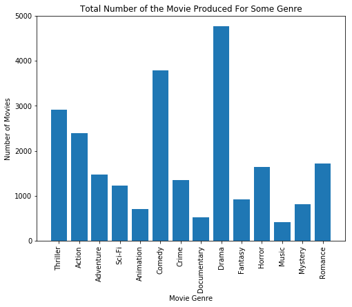

```python
# Total number of different movies genre produced
adv_count = df_genre.adventure.sum()
action_count = df_genre.action.sum()
anime_count = df_genre.animation.sum()
comedy_count = df_genre.comedy.sum()
crime_count = df_genre.crime.sum()
docum_count = df_genre.docum.sum()
drama_count = df_genre.drama.sum()
fantasy_count = df_genre.fantasy.sum()
horror_count = df_genre.horror.sum()
music_count = df_genre.music.sum()
mystery_count = df_genre.mystery.sum()
romance_count = df_genre.romance.sum()
sci_count = df_genre.sci_fi.sum()
thriller_count = df_genre.thriller.sum()

total_genre_list = [thriller_count, action_count, adv_count, sci_count,
                    anime_count, comedy_count, crime_count, docum_count,
                    drama_count, fantasy_count, horror_count, music_count,
                    mystery_count, romance_count]

genre_label = ['Thriller', 'Action', 'Adventure', 'Sci-Fi', 'Animation',
               'Comedy', 'Crime', 'Documentary', 'Drama', 'Fantasy',
               'Horror', 'Music', 'Mystery', 'Romance']

# plot bar chart
plt.figure(figsize=(8,6))
plt.bar(np.arange(0,14), total_genre_list)
plt.xticks(np.arange(0,14), genre_label, rotation=90)
plt.title('Total Number of the Movie Produced For Some Genre')
plt.xlabel('Movie Genre')
plt.ylabel('Number of Movies');
```

More drama, comedy and thriller movies have been produced.

### Question 17: Which movie genre generated the highest average revenue? (Compare Action, Adventure, Thriller, Drama, Sci-Fi)

```python
def compare_genre(column_name, title, xlabel, ylabel):
    """"Fuction to compare the some movie genres with a numeric column

    column_name: str, attribute: which is the column name,
    title: str, title of the plot,
    xlabel: str, label of the x axis,
    ylabel: str, label of the y axis.
    """

    # use the getattr function to treat the column_name parameter
    # as an attribute of the df_genre dataframe

    adv = getattr(df_genre.query('adventure==True'), column_name).mean()
    action = getattr(df_genre.query('action==True'), column_name).mean()
    thriller = getattr(df_genre.query('thriller==True'), column_name).mean()
    sci = getattr(df_genre.query('sci_fi==True'), column_name).mean()
    drama = getattr(df_genre.query('drama==True'), column_name).mean()

    xlist = [adv, action, thriller, sci, drama]
    label = ["Adventure", "Action", "Thriller", "Sci_Fi", "Drama"]

    # plot bar chart
    plt.figure(figsize=(8,6))
    plt.bar(np.arange(0,5), xlist)
    plt.xticks(np.arange(0,5), label, rotation=90)
    plt.title(title, size=14)
    plt.xlabel(xlabel)
    plt.ylabel(ylabel);
```

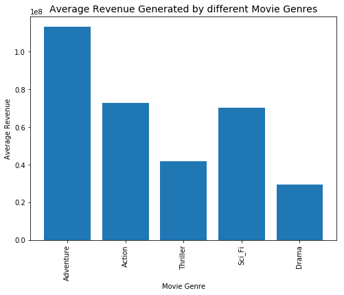

```python
# compare the genres with the revenue

compare_genre('revenue',
              title='Average Revenue Generated by different Movie Genres',
              xlabel='Movie Genre',
              ylabel='Average Revenue')
```

Between `Adventure`, `Action`, `Thriller`, `Sci_Fi`, `Drama` movie genres, The `Adventure` movie genre has generate the highest average revenue.

### Question 18: Which movie genre has the highest average budget? (Compare Action, Adventure, Thriller, Drama, Sci-Fi)

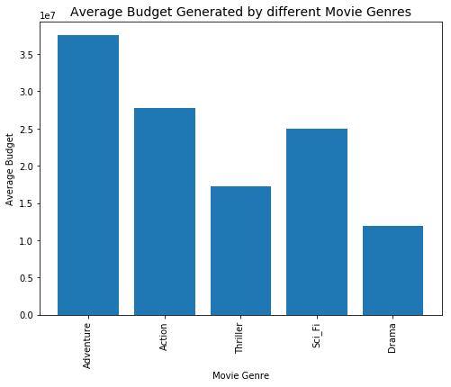

```python
# compare the genres with the budget

compare_genre('budget',
              title='Average Budget Generated by different Movie Genres',
              xlabel='Movie Genre',
              ylabel='Average Budget')
```

Between `Adventure`, `Action`, `Thriller`, `Sci_Fi`, `Drama` movie genres, more money is spent on `Adventure`, `Action` and `Sci-Fi` movies.

### Question 19: Which movie genre has the highest average vote count? (Compare Action, Adventure, Thriller, Drama, Sci-Fi)

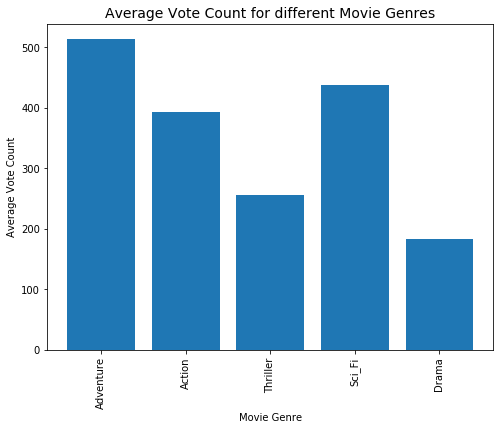

```python
# compare the genres with the vote count

compare_genre('vote_count',
              title='Average Vote Count for different Movie Genres',
              xlabel='Movie Genre',
              ylabel='Average Vote Count')
```

Between `Adventure`, `Action`, `Thriller`, `Sci_Fi`, `Drama` movie genres, most fans vote for `Adventure`, `Sci-Fi` and `Action` movies.

### Question 20: Which movie genre has the highest average vote average? (Compare Action, Adventure, Thriller, Drama, Sci-Fi)

[figure not shown]

```python
# compare the genres with the vote average

compare_genre('vote_average',
              title='Average Vote Count for different Movie Genres',
              xlabel='Movie Genre',
              ylabel='Average Vote Average')
```

`Drama` and `Adventure` movies have the highest average vote average.

### Question 21: Which movie genre has the highest average runtime? (Compare Action, Adventure, Thriller, Drama, Sci-Fi)

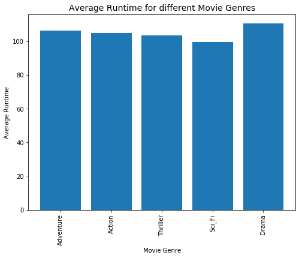

```python
# compare the genres with the runtime

compare_genre('runtime',
              title='Average Runtime for different Movie Genres',
              xlabel='Movie Genre',
              ylabel='Average Runtime')
```

On average, `Drama` movies have the longest runtime.

### Question 22: Which movie genre has the highest average popularity? (Compare Action, Adventure, Thriller, Drama, Sci-Fi)

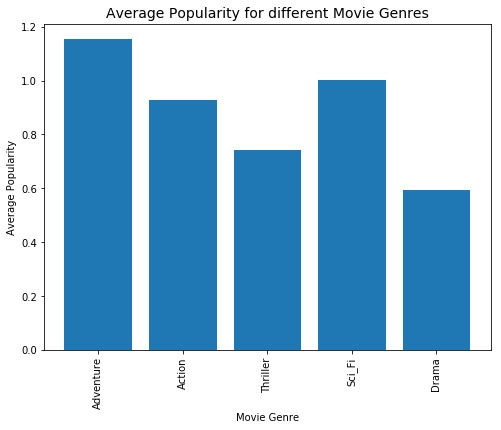

```python
# compare the genres with the popularity

compare_genre('popularity',
              title='Average Popularity for different Movie Genres',
              xlabel='Movie Genre',
              ylabel='Average Popularity')
```

`Adventure` movies are more popular than the other genres in the chart above.

## Conclusions

**Data Cleaning**

1. There are missing data in the following columns: imdb_id, cast, homepage, director, tagline, keywords, overview, genres, production_companies.
2. I removed the columns. There was also a duplicate row. I removed the duplicate row.
3. There were `10866` records and `21` columns in the dataset. After cleaning, there were `10865` records and `10` columns.

## Submitting your Project

> **Tip**: Before you submit your project, you need to create a .html or .pdf version of this notebook in the workspace here. To do that, run the code cell below. If it worked correctly, you should get a return code of 0, and you should see the generated .html file in the workspace directory (click on the orange Jupyter icon in the upper left).

> **Tip**: Alternatively, you can download this report as .html via the **File** > **Download as** submenu, and then manually upload it into the workspace directory by clicking on the orange Jupyter icon in the upper left, then using the Upload button.

> **Tip**: Once you've done this, you can submit your project by clicking on the "Submit Project" button in the lower right here. This will create and submit a zip file with this .ipynb doc and the .html or .pdf version you created. Congratulations!

```python
from subprocess import call
call(['python', '-m', 'nbconvert', 'Investigate_a_Dataset.ipynb'])
```

```
255
```